# 大作业--数据分析与可视化

## 1.算法简介

在介绍kmeans算法之前，我像在这里介绍一个小故事：

> 有四个牧师去郊区布道，一开始牧师们随意选了几个布道点，并且把这几个布道点的情况公告给了郊区所有的村民，于是每个村民到离自己家最近的布道点去听课。 听课之后，大家觉得距离太远了，于是每个牧师统计了一下自己的课上所有的村民的地址，搬到了所有地址的中心地带，并且在海报上更新了自己的布道点的位置。 牧师每一次移动不可能离所有人都更近，有的人发现A牧师移动以后自己还不如去B牧师处听课更近，于是每个村民又去了离自己最近的布道点…… 就这样，牧师每个礼拜更新自己的位置，村民根据自己的情况选择布道点，最终稳定了下来。

这个故事中牧师们选择布道点的方法，其实就是kmeans算法的思想，即：为了让每个村民（样本点）到其最近布道点（质心）的距离和最小。

下面是kmeans算法的具体内容：

k-means 算法的处理流程如下。首先，随机地选择 k 个数据对象，每个数据对象代表一个簇中心，即选择 k 个初始中心；对剩余的每个对象，根据其与各簇中心的相似度（距离），将它赋给与其最相似的簇中心对应的簇；然后重新计算每个簇中所有对象的平均值，作为新的簇中心。

不断重复以上这个过程，直到准则函数收敛，也就是簇中心不发生明显的变化。通常采用均方差作为准则函数，即最小化每个点到最近簇中心的距离的平方和。

其算法流程为： 所以 K-means 的算法步骤为：

1. 选择初始化的 k 个样本作为初始聚类中心$a=a_1,a_2,...a_k$
2. 针对数据集中每个样本$x_i$计算它到 k 个聚类中心的距离并将其分到距离最小的聚类中心所对应的类中
3. 针对每个类别$a_j$，重新计算它的聚类中心$a_j=\frac 1{|c_j|}\sum_{x \in c_i}x$（即属于该类的所有样本的质心）
4. 重复上面 2 3 两步操作，直到达到某个中止条件（迭代次数、最小误差变化等）。

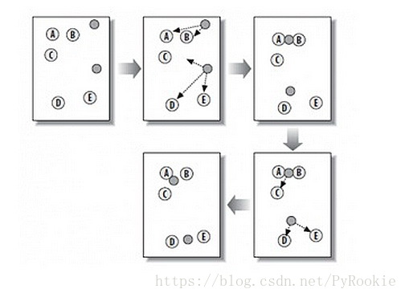

## 2.kmeans算法实现

### 2.1自编代码部分

注：以下代码均为本人自主编写，不存在抄袭现象

```python
import numpy as np
import math
import matplotlib.pyplot as plt
import copy
```

```python
def my_Kmeans(data,k):
    '''
    data为二维的np.array，每一维分别对应点的横纵坐标；
    k为integer，对应簇数；
    '''
#参数初始化：
    means_points=[]    #记录质点位置
    categories=[]      #记录聚类结果
    categories_new=[]  #记录更新后聚类结果
    initial=[]         #用于初始化和辅助判断

    for i in np.random.randint(0,len(data),k):
        means_points.append(data[i])
    #means_points.append(data[5])
    #means_points.append(data[11])
    #means_points.append(data[26])
    for i in range(k):
        categories.append([])
        categories_new.append([])
        initial.append([])

#K-means聚类
    #进行一次聚类
    for i in data:
        d=[]  #距离
        for j in means_points:
            d.append(math.sqrt((i[0]-j[0])**2+(i[1]-j[1])**2))
        categories[d.index(min(d))].append(i)

    #进入迭代
    times=0
    while(categories!=categories_new):  #两次结果相同，则跳出迭代
        times+=1
    #两次结果不同，则更新聚类结果
        if categories_new!=initial:
            categories=copy.deepcopy(categories_new)
    #更新质心
        for i in range(len(categories)):
            sum_x,sum_y=0,0
            for j in range(len(categories[i])):
                sum_x+=categories[i][j][0]
                sum_y+=categories[i][j][1]
            means_points[i]=[sum_x/len(categories[i]),sum_y/len(categories[i])]

    #再聚类
        categories_new=copy.deepcopy(initial)
        for i in data:
            d=[]  #距离
            for j in means_points:
                d.append(math.sqrt((i[0]-j[0])**2+(i[1]-j[1])**2))
            categories_new[d.index(min(d))].append(i)


    return categories,times
```

#### 测试部分

```python
#导入西瓜数据集4.0
data = [
    [0.697, 0.460], [0.774, 0.376], [0.634, 0.264], [0.608, 0.318], [0.556, 0.215],
    [0.403, 0.237], [0.481, 0.149], [0.437, 0.211], [0.666, 0.091], [0.243, 0.267],
    [0.245, 0.057], [0.343, 0.099], [0.639, 0.161], [0.657, 0.198], [0.360, 0.370],
    [0.593, 0.042], [0.719, 0.103], [0.359, 0.188], [0.339, 0.241], [0.282, 0.257],
    [0.748, 0.232], [0.714, 0.346], [0.483, 0.312], [0.478, 0.437], [0.525, 0.369],
    [0.751, 0.489], [0.532, 0.472], [0.473, 0.376], [0.725, 0.445], [0.446, 0.459]
]
```

**k=3**

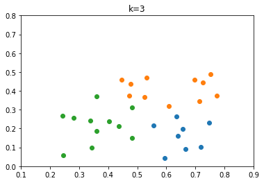

```
times of iteration: 7
```

```python
k=3
ctgrs,time=my_Kmeans(data,k)

x,y=[],[]
for i in range(len(ctgrs)):
    x.append([])
    y.append([])
    for j in range(len(ctgrs[i])):
        x[i].append(ctgrs[i][j][0])
        y[i].append(ctgrs[i][j][1])
    plt.scatter(x[i],y[i])

plt.xlim((0.1,0.9))
plt.ylim((0,0.8))
plt.title("k=3")
plt.show()
print('times of iteration:',time)
```

**k=4**

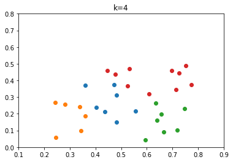

```
times of iteration: 1
```

```python
k=4
ctgrs,time=my_Kmeans(data,k)

x,y=[],[]
for i in range(len(ctgrs)):
    x.append([])
    y.append([])
    for j in range(len(ctgrs[i])):
        x[i].append(ctgrs[i][j][0])
        y[i].append(ctgrs[i][j][1])
    plt.scatter(x[i],y[i])

plt.xlim((0.1,0.9))
plt.ylim((0,0.8))
plt.title("k=4")
plt.show()
print('times of iteration:',time)
```

**k=5**

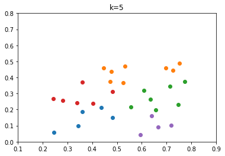

```
times of iteration: 2
```

```python
k=5
ctgrs,time=my_Kmeans(data,k)

x,y=[],[]
for i in range(len(ctgrs)):
    x.append([])
    y.append([])
    for j in range(len(ctgrs[i])):
        x[i].append(ctgrs[i][j][0])
        y[i].append(ctgrs[i][j][1])
    plt.scatter(x[i],y[i])

plt.xlim((0.1,0.9))
plt.ylim((0,0.8))
plt.title("k=5")
plt.show()
print('times of iteration:',time)
```

由此可见,k=4时聚类效果较好。

### 2.2 sklearn中的kmeans

```python
from sklearn.cluster import KMeans
```

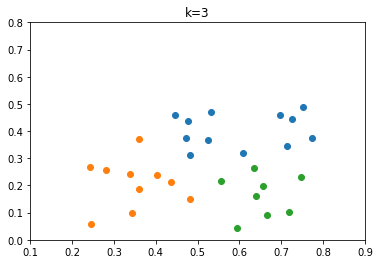

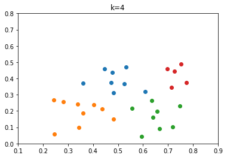

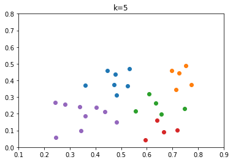

```python
#模型拟合及数据可视化
for k in range(3,6):
    km=KMeans(n_clusters=k)
    result=km.fit_predict(data)
    x,y=[],[]
    for i in range(k):
        x.append([])
        y.append([])

    for i in range(len(result)):
        x[result[i]].append(data[i][0])
        y[result[i]].append(data[i][1])

    for i in range(k):
        plt.scatter(x[i],y[i])
    plt.xlim((0.1,0.9))
    plt.ylim((0,0.8))
    plt.title('k=%d'%(k))
    plt.show()
```

可以看出，自己编写的算法和sklearn中的算法得到的结果稍有不同，但差别不大，这是由于初始质心的选取和质心更新规则造成的。 当然，sklearn的算法一定比我自己编写的更全面，因此下面案例中利用skleran的KMeans算法进行数据处理

## 3.数据分析案例

### 3.1 数据导入与预处理

```python
import pandas as pd
import numpy as np
from sklearn.cluster import KMeans
from sklearn.metrics import silhouette_score,silhouette_samples      #轮廓系数
from sklearn.preprocessing import StandardScaler
from sklearn.preprocessing import LabelEncoder        # 导入标签编码
```

```python
import matplotlib.pyplot as plt
```

```python
import matplotlib.cm as cm
```

```python
#读取文件
path=r'D:\Ugorgeous\LLLLearning\COURSES\python语言程序设计\car_price.csv'
case_data0=pd.read_csv(path)
```

```python
#查看数据组成情况
case_data0.head()
```

|  | car_ID | symboling | CarName | fueltype | aspiration | doornumber | carbody | drivewheel | enginelocation | wheelbase | ... | enginesize | fuelsystem | boreratio | stroke | compressionratio | horsepower | peakrpm | citympg | highwaympg | price |
| --- | --- | --- | --- | --- | --- | --- | --- | --- | --- | --- | --- | --- | --- | --- | --- | --- | --- | --- | --- | --- | --- |
| 0 | 1 | 3 | alfa-romero giulia | gas | std | two | convertible | rwd | front | 88.6 | ... | 130 | mpfi | 3.47 | 2.68 | 9.0 | 111 | 5000 | 21 | 27 | 13495.0 |
| 1 | 2 | 3 | alfa-romero stelvio | gas | std | two | convertible | rwd | front | 88.6 | ... | 130 | mpfi | 3.47 | 2.68 | 9.0 | 111 | 5000 | 21 | 27 | 16500.0 |
| 2 | 3 | 1 | alfa-romero Quadrifoglio | gas | std | two | hatchback | rwd | front | 94.5 | ... | 152 | mpfi | 2.68 | 3.47 | 9.0 | 154 | 5000 | 19 | 26 | 16500.0 |
| 3 | 4 | 2 | audi 100 ls | gas | std | four | sedan | fwd | front | 99.8 | ... | 109 | mpfi | 3.19 | 3.40 | 10.0 | 102 | 5500 | 24 | 30 | 13950.0 |
| 4 | 5 | 2 | audi 100ls | gas | std | four | sedan | 4wd | front | 99.4 | ... | 136 | mpfi | 3.19 | 3.40 | 8.0 | 115 | 5500 | 18 | 22 | 17450.0 |

5 rows × 26 columns

```python
# 缺失值检测
print(case_data0.isnull().sum())
```

```
car_ID              0
symboling           0
CarName             0
fueltype            0
aspiration          0
doornumber          0
carbody             0
drivewheel          0
enginelocation      0
wheelbase           0
carlength           0
carwidth            0
carheight           0
curbweight          0
enginetype          0
cylindernumber      0
enginesize          0
fuelsystem          0
boreratio           0
stroke              0
compressionratio    0
horsepower          0
peakrpm             0
citympg             0
highwaympg          0
price               0
dtype: int64
```

```python
#特征编码，将字符类型特征转换为数值类型特征

#提取字符类型特征
TrainColumn = case_data0.columns.drop(['car_ID', 'symboling', 'CarName'])
Train = case_data0[TrainColumn]
CategoryColumn = Train.select_dtypes(include = 'object').columns
pd.set_option('mode.chained_assignment', None)

print('转换前：')
for i in CategoryColumn:
    print(i)
    print(set(Train[i]))

# 对字符类型特征进行标签编码
for i in CategoryColumn:
    Train[i] = LabelEncoder().fit_transform(Train[i])

print('转换后：')
for i in CategoryColumn:
    print(i)
    print(set(Train[i]))
```

```
转换前：
fueltype
{'diesel', 'gas'}
aspiration
{'turbo', 'std'}
doornumber
{'four', 'two'}
carbody
{'convertible', 'sedan', 'wagon', 'hardtop', 'hatchback'}
drivewheel
{'rwd', '4wd', 'fwd'}
enginelocation
{'rear', 'front'}
enginetype
{'ohcf', 'ohcv', 'ohc', 'dohc', 'dohcv', 'l', 'rotor'}
cylindernumber
{'four', 'six', 'eight', 'five', 'three', 'two', 'twelve'}
fuelsystem
{'mfi', '2bbl', 'spdi', 'spfi', '1bbl', 'idi', '4bbl', 'mpfi'}
转换后：
fueltype
{0, 1}
aspiration
{0, 1}
doornumber
{0, 1}
carbody
{0, 1, 2, 3, 4}
drivewheel
{0, 1, 2}
enginelocation
{0, 1}
enginetype
{0, 1, 2, 3, 4, 5, 6}
cylindernumber
{0, 1, 2, 3, 4, 5, 6}
fuelsystem
{0, 1, 2, 3, 4, 5, 6, 7}
```

```python
#选取部分数据
case_data=Train
case_data=case_data.loc[:,['fueltype','aspiration','doornumber','carbody','drivewheel','fuelsystem','horsepower','price']]
case_data.describe()
```

|  | fueltype | aspiration | doornumber | carbody | drivewheel | fuelsystem | horsepower | price |
| --- | --- | --- | --- | --- | --- | --- | --- | --- |
| count | 205.000000 | 205.000000 | 205.000000 | 205.000000 | 205.000000 | 205.000000 | 205.000000 | 205.000000 |
| mean | 0.902439 | 0.180488 | 0.439024 | 2.614634 | 1.326829 | 3.253659 | 104.117073 | 13276.710571 |
| std | 0.297446 | 0.385535 | 0.497483 | 0.859081 | 0.556171 | 2.013204 | 39.544167 | 7988.852332 |
| min | 0.000000 | 0.000000 | 0.000000 | 0.000000 | 0.000000 | 0.000000 | 48.000000 | 5118.000000 |
| 25% | 1.000000 | 0.000000 | 0.000000 | 2.000000 | 1.000000 | 1.000000 | 70.000000 | 7788.000000 |
| 50% | 1.000000 | 0.000000 | 0.000000 | 3.000000 | 1.000000 | 5.000000 | 95.000000 | 10295.000000 |
| 75% | 1.000000 | 0.000000 | 1.000000 | 3.000000 | 2.000000 | 5.000000 | 116.000000 | 16503.000000 |
| max | 1.000000 | 1.000000 | 1.000000 | 4.000000 | 2.000000 | 7.000000 | 288.000000 | 45400.000000 |

```python
#由于sklearn中K-Means聚类算法仅支持二维数组运算，所以要先将数据集转化为二维数组：
case_data = np.array(case_data,type(float))
case_data
```

```
array([[1.0, 0.0, 1.0, ..., 5.0, 111.0, 13495.0],
       [1.0, 0.0, 1.0, ..., 5.0, 111.0, 16500.0],
       [1.0, 0.0, 1.0, ..., 5.0, 154.0, 16500.0],
       ...,
       [1.0, 0.0, 0.0, ..., 5.0, 134.0, 21485.0],
       [0.0, 1.0, 0.0, ..., 3.0, 106.0, 22470.0],
       [1.0, 1.0, 0.0, ..., 5.0, 114.0, 22625.0]], dtype=object)
```

### 3.2 模型拟合与数据可视化

本模型采用轮廓系数进行聚类效果评估：

对于某一样本点来说，当值越接近1时就代表自身与所在的簇中其他样本越相似，并且与其他簇中的样本不相似，而当值越接近-1时则代表与上述内容相反；综述，轮廓系数越接近1越好，负数则表示聚类效果非常差；

```python
#测试模型与评价指标，取k=4
km=KMeans(n_clusters=4,random_state=0).fit(case_data)
#查看轮廓系数均值
silhouette_score(case_data,km.labels_)
#查看每轮轮廓系数
#silhouette_samples(case_data,km.labels_)
```

```
0.5974287511329665
```

```python
#查看数据标准化后的聚类效果
std = StandardScaler()
x0=std.fit_transform(case_data)
#测试模型与评价指标，取k=4
km=KMeans(n_clusters=4,random_state=0).fit(x0)
#查看轮廓系数均值
silhouette_score(x0,km.labels_)
```

```
0.33682280835906225
```

可见，数据标准化后聚类效果**很差**，故不采用标准化

```python
#进行初步聚类，查找k的大致范围
score=[]
for k in [2,4,6,8,10,12]:
    km=KMeans(n_clusters=k,random_state=0).fit(case_data)
    score.append((k,silhouette_score(case_data,km.labels_)))
print(score)
```

[output not shown]

```python
#进行初步聚类，k值选择在2至10之间
score=[]
SSE=[]
for k in range(2,11):
    km=KMeans(n_clusters=k,random_state=0).fit(case_data)
    score.append((k,silhouette_score(case_data,km.labels_)))
    SSE.append(km.inertia_)
print(score)
```

```
[(2, 0.7206385945434857), (3, 0.6703657027816045), (4, 0.5974287511329665), (5, 0.6014808037201474), (6, 0.6030067519110853), (7, 0.5710786120983455), (8, 0.5727937730746919), (9, 0.5524806080678796), (10, 0.5437235812881314)]
```

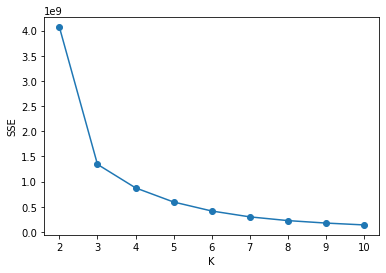

```python
#查看样本到其最近的聚类中心的平方距离之和
X = range(2, 11)
plt.xlabel('K')
plt.ylabel('SSE')
plt.plot(X, SSE, 'o-')
```

```
簇数为 2 ，轮廓系数均值为 0.7206385945434857
```

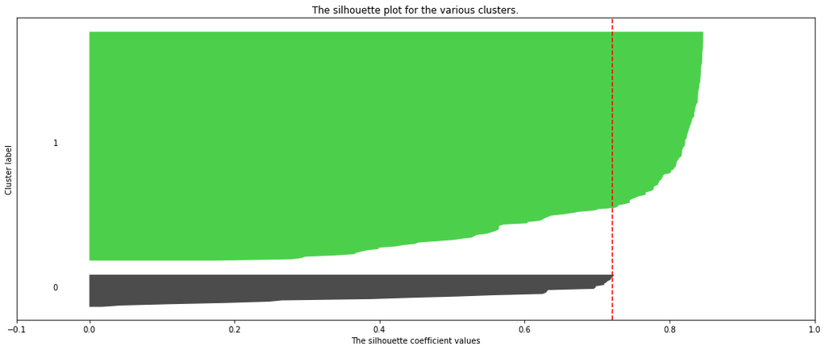

```
簇数为 3 ，轮廓系数均值为 0.6703657027816045
```

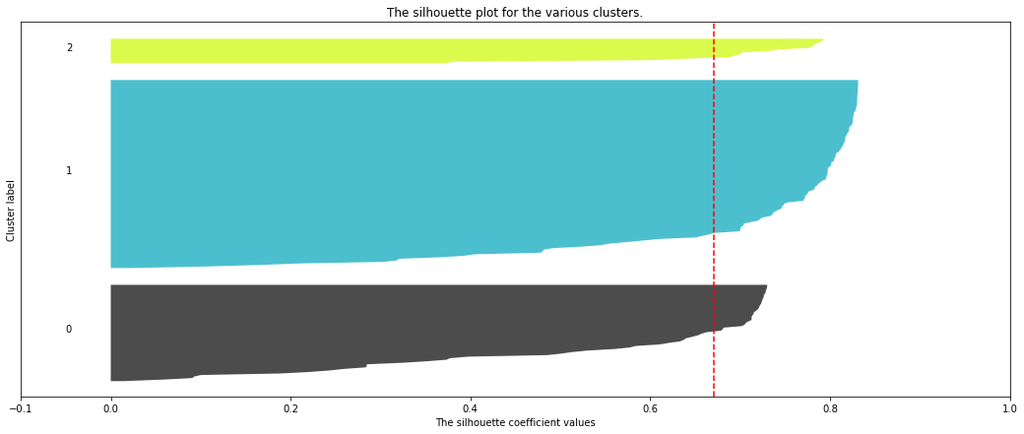

```
簇数为 4 ，轮廓系数均值为 0.5974287511329665
```

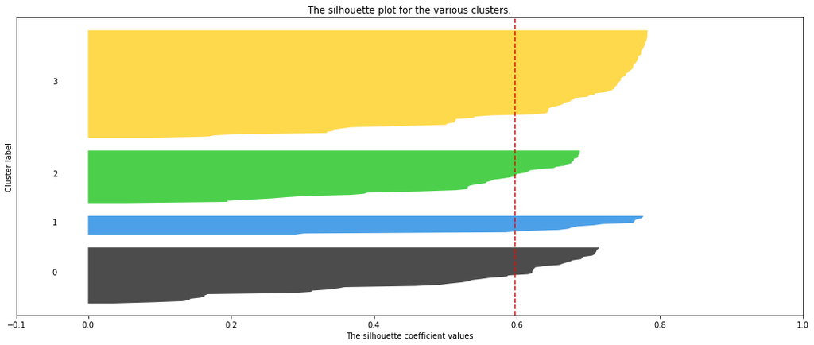

```
簇数为 5 ，轮廓系数均值为 0.6014808037201474
```

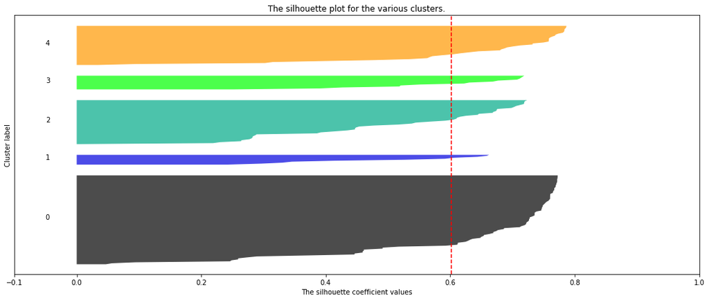

```
簇数为 6 ，轮廓系数均值为 0.6030067519110853
```

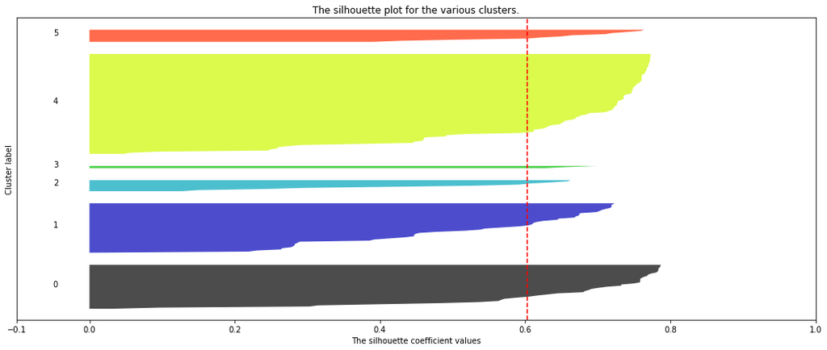

```
簇数为 7 ，轮廓系数均值为 0.5703795196193631
```

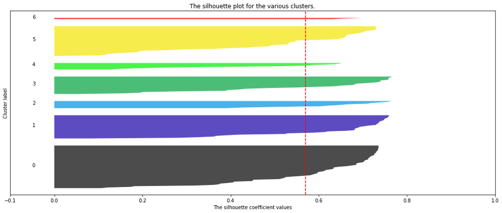

```
簇数为 8 ，轮廓系数均值为 0.5727937730746919
```

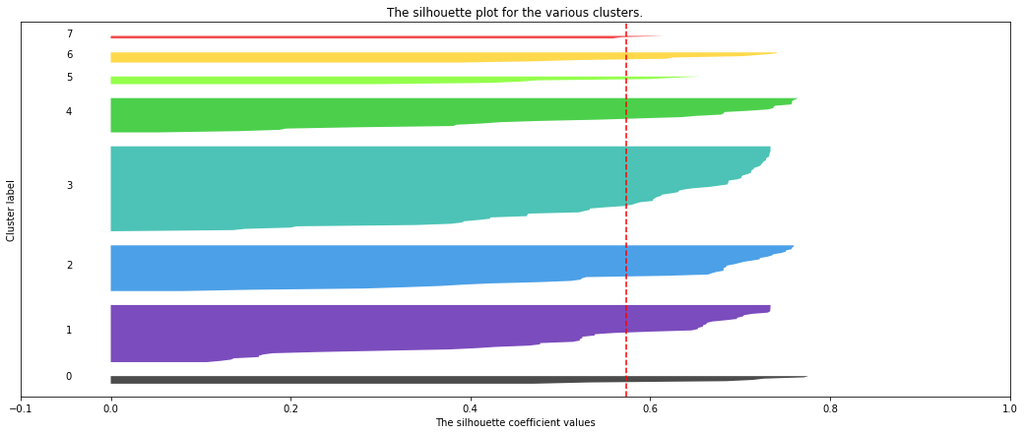

```python
#查看轮廓系数分布图，同时由上面的结果，选取k值在2至8之间
for n_clusters in [2,3,4,5,6,7,8]:
    n_clusters = n_clusters
    # 设置画布
    fig, ax1 = plt.subplots(1)
    # 设置画布尺寸
    fig.set_size_inches(18, 7)
    # 设置画布X轴
    ax1.set_xlim([-0.1, 1])
    # 设置画布Y轴：X.shape[0]代表着柱状的宽度，(n_clusters + 1) * 10代表着柱与柱之间的间隔
    ax1.set_ylim([0, case_data.shape[0] + (n_clusters + 1) * 10])
    # 模型实例化
    clusterer = KMeans(n_clusters=n_clusters, random_state=100)
    # 开始训练模型
    clusterer = clusterer.fit(case_data)
    # 提取训练结果中的预测标签
    cluster_labels = clusterer.labels_
    # 提取训练结果中的轮廓系数均值
    silhouette_avg = silhouette_score(case_data, cluster_labels)
    # 打印出当前的簇数与轮廓系数均值
    print("簇数为", n_clusters,
          "，轮廓系数均值为", silhouette_avg)
    # 提取每一个样本的轮廓系数
    sample_silhouette_values = silhouette_samples(case_data, cluster_labels)
    # 设置Y轴的起始坐标
    y_lower = 10
    # 添加一个循环，把每一个样本的轮廓系数画在图中
    for i in range(n_clusters):
        # 提取第i个簇下的所有样本轮廓系数
        ith_cluster_silhouette_values = sample_silhouette_values[cluster_labels == i]
        # 对样本的轮廓系数进行排序（降序）
        ith_cluster_silhouette_values.sort()
        # 设置当前簇的柱状宽度（使用样本数量）以便于设置下一个簇的起始坐标
        size_cluster_i = ith_cluster_silhouette_values.shape[0]
        # 设置Y轴第i个簇的起始坐标
        y_upper = y_lower + size_cluster_i
        # 设置颜色
        color = cm.nipy_spectral(float(i)/n_clusters)
        # 画图
        ax1.fill_betweenx(np.arange(y_lower, y_upper)
                         ,ith_cluster_silhouette_values
                         ,facecolor=color
                         ,alpha=0.7
                         )
        ax1.text(-0.05
                 , y_lower + 0.5 * size_cluster_i
                 , str(i))
        y_lower = y_upper + 10
    # 设置图的标题
    ax1.set_title("The silhouette plot for the various clusters.")
    ax1.set_xlabel("The silhouette coefficient values")
    ax1.set_ylabel("Cluster label")
    # 添加轮廓系数均值线，使用虚线
    ax1.axvline(x=silhouette_avg, color="red", linestyle="--")
    ax1.set_yticks([])
    ax1.set_xticks([-0.1, 0, 0.2, 0.4, 0.6, 0.8, 1])
    plt.show()
```

从本次的输出结果中可知，当簇数量为2时，会存在最大的轮廓系数均值,但我们可以通过轮廓系数分部图看到，基本上每一个图内都会有一片**面积很大的块**，这是**长尾数据**带来的，因为数据基本都集中在一个点上，所以导致整体轮廓系数均值“被平均”得很大，

因此这并不是好的聚类的结果。

因此初步选择k=3

```python
# 查看每一分类结果的数量
km=KMeans(n_clusters=3,random_state=0).fit(case_data)
pd.value_counts(km.labels_)
```

```
1    124
0     64
2     17
dtype: int64
```

可以看出，k=3时并没有出现“长尾数据”的结果，因此选择k=3.

注：由于个人能力和知识储备的原因，本次数据分析并没有做到完整、全面的数据挖掘处理。

如特征处理、特征编码可以根据实际情况或查阅相关论文资料进行更加准确编码，模型也可以使用更多的指标进行评价...

即本案例处理还有**很大的进步空间**。

继续努力！